# Case 31: Summary of Data Analysis for R3, R6, and R4

Employees Federal Credit Union (EFCU)

Author

Ruben Garcia

# 1 Overview

This report summarizes the analysis for three research questions in the EFCU member survey:

- **R3:** What are members’ attitudes and beliefs about the proficiency of credit union employees?
- **R6:** What are members’ attitudes and beliefs about how effectively the credit union is operated?
- **R4:** Do members who live in the headquarters area differ from members who live elsewhere in (a) attitude toward employee proficiency, (b) awareness of services, and (c) operational effectiveness?

**How the earlier reliability and factor analyses shape this report.** Those results are reported in the previous assignment, so they are not repeated here; only the decisions are used:

- Q3 to Q6 formed one reliable factor, so they are combined into a single **employee proficiency score** (`att_employee`, the mean of Q3 to Q6) for R3 and R4a.
- Q31 to Q34 did not form a reliable scale, so no composite is made. In R6 and R4c these four items are analyzed **one at a time**.

Throughout, I look at frequencies and means first, describe the story the data tell, and then use statistical tests to confirm it. Test statistics are kept inside parentheses.

```r
library(tidyverse)
library(haven)
library(labelled)
library(gt)

theme_set(theme_minimal(base_size = 13))
```

```r
# Cleaned data from IC10-2-1 (keeps value labels and variable labels)
data <- read_sav("Case 31 Data_efcu_1_RG_cleaned.sav")

# Plain-number copy for means, t-tests, and percentages
data_numeric <- data |>
  mutate(across(everything(), as.numeric))

n_respondents <- nrow(data)
```

```r
# Step 1: employee proficiency score (mean of Q3 to Q6, kept on the 1-5 scale)
data_analysis <- data_numeric |>
  mutate(att_employee = rowMeans(pick(q3:q6)))

# Step 2: member residence as a labeled grouping variable (Q38: 1 = yes, 2 = no)
data_analysis <- data_analysis |>
  mutate(
    residence = factor(
      q38,
      levels = c(1, 2),
      labels = c("Lives in HQ area", "Lives elsewhere")
    )
  )

# Group sizes
data_analysis |> count(residence)
```

```
# A tibble: 2 × 2
  residence            n
  <fct>            <int>
1 Lives in HQ area    57
2 Lives elsewhere     71
```

```r
# ---- formatting helpers ----
fmt_p <- function(p) {
  if_else(p < .001, "p < .001", paste0("p = ", sub("^0", "", sprintf("%.3f", p))))
}

# ---- frequency table with value labels ----
distribution_table <- function(variable_name) {
  variable_labelled <- data[[variable_name]]

  codes <- as.numeric(variable_labelled)
  labels_text <- as.character(as_factor(variable_labelled))

  raw_table <- tibble(code = codes, response = labels_text)
  raw_table <- raw_table |>
    mutate(response = replace_na(response, "No opinion / no answer (missing)"))

  counts <- raw_table |> count(code, response)
  n_valid <- sum(counts |> filter(!is.na(code)) |> pull(n))

  counts |>
    mutate(
      variable = variable_name,
      percent_of_valid = if_else(is.na(code), NA_real_, round(n / n_valid * 100, 1))
    ) |>
    arrange(code) |>
    select(variable, code, response, n, percent_of_valid)
}

get_percent <- function(freq_table, code_value) {
  freq_table |> filter(code == code_value) |> pull(percent_of_valid)
}

# ---- one-sample t-test against the scale midpoint of 3 ----
one_sample_row <- function(variable_name, description, test_value = 3) {
  all_values <- data_analysis[[variable_name]]
  valid_values <- all_values[!is.na(all_values)]

  test_result <- t.test(valid_values, mu = test_value)
  test_tidy <- broom::tidy(test_result)

  tibble(
    item = variable_name,
    description = description,
    n = length(valid_values),
    mean = mean(valid_values),
    sd = sd(valid_values),
    percent_4_or_5 = mean(valid_values >= 4) * 100,
    t = test_tidy |> pull(statistic),
    df = test_tidy |> pull(parameter),
    p = test_tidy |> pull(p.value),
    conf_low = test_tidy |> pull(conf.low),
    conf_high = test_tidy |> pull(conf.high)
  )
}

# ---- independent-groups (Welch) t-test by residence ----
group_ttest_row <- function(variable_name, description) {
  test_data <- data_analysis |>
    select(residence, value = all_of(variable_name)) |>
    drop_na()

  group_summary <- test_data |>
    summarise(n = n(), mean = mean(value), sd = sd(value), .by = residence)

  hq_row <- group_summary |> filter(residence == "Lives in HQ area")
  else_row <- group_summary |> filter(residence == "Lives elsewhere")

  n_hq <- hq_row |> pull(n)
  n_else <- else_row |> pull(n)
  mean_hq <- hq_row |> pull(mean)
  mean_else <- else_row |> pull(mean)
  sd_hq <- hq_row |> pull(sd)
  sd_else <- else_row |> pull(sd)

  pooled_sd <- sqrt(((n_hq - 1) * sd_hq^2 + (n_else - 1) * sd_else^2) / (n_hq + n_else - 2))

  test_result <- t.test(value ~ residence, data = test_data)
  test_tidy <- broom::tidy(test_result)

  tibble(
    item = variable_name,
    description = description,
    n_hq = n_hq,
    mean_hq = mean_hq,
    sd_hq = sd_hq,
    n_else = n_else,
    mean_else = mean_else,
    sd_else = sd_else,
    difference = mean_hq - mean_else,
    t = test_tidy |> pull(statistic),
    df = test_tidy |> pull(parameter),
    p = test_tidy |> pull(p.value),
    cohens_d = (mean_hq - mean_else) / pooled_sd
  )
}

# ---- chi-square test of independence by residence ----
# Fisher's exact test is used when any expected count is below 5
chisq_row <- function(variable_name, description) {
  test_data <- data_analysis |>
    select(residence, value = all_of(variable_name)) |>
    drop_na()

  crosstab <- table(test_data |> pull(residence), test_data |> pull(value))

  chi_result <- suppressWarnings(chisq.test(crosstab, correct = FALSE))
  fisher_result <- fisher.test(crosstab)

  n_total <- sum(crosstab)
  chi_value <- as.numeric(chi_result |> pluck("statistic"))
  min_expected <- min(chi_result |> pluck("expected"))

  tibble(
    item = variable_name,
    description = description,
    n = n_total,
    chi_square = chi_value,
    df = as.numeric(chi_result |> pluck("parameter")),
    p_chi = chi_result |> pluck("p.value"),
    p_fisher = fisher_result |> pluck("p.value"),
    min_expected = min_expected,
    cramers_v = sqrt(chi_value / (n_total * (min(dim(crosstab)) - 1)))
  ) |>
    mutate(p_reported = if_else(min_expected < 5, p_fisher, p_chi))
}
```

# 2 R3: Attitudes toward employee proficiency

## 2.1 Descriptive statistics

```r
r3_labels <- c(
  q3 = "Q3: Employees are courteous",
  q4 = "Q4: Employees are helpful",
  q5 = "Q5: Employees are professional",
  q6 = "Q6: Employees are always available"
)

r3_long <- data_numeric |>
  select(q3:q6) |>
  pivot_longer(everything(), names_to = "item", values_to = "response")

r3_summary <- r3_long |>
  summarise(
    mean = mean(response),
    sd = sd(response),
    percent_disagree = mean(response <= 2) * 100,
    percent_uncertain = mean(response == 3) * 100,
    percent_agree = mean(response >= 4) * 100,
    .by = item
  )

r3_summary <- r3_summary |>
  mutate(statement = r3_labels[item]) |>
  select(statement, mean, sd, percent_disagree, percent_uncertain, percent_agree)

r3_summary |>
  gt() |>
  fmt_number(columns = c(mean, sd, percent_disagree, percent_uncertain, percent_agree), decimals = 1) |>
  cols_label(
    statement = "Statement",
    mean = "Mean",
    sd = "SD",
    percent_disagree = "% disagree (1-2)",
    percent_uncertain = "% uncertain (3)",
    percent_agree = "% agree (4-5)"
  )
```

Table 1: R3: Agreement with each employee statement (percent of respondents, n = 128)

| Statement | Mean | SD | % disagree (1-2) | % uncertain (3) | % agree (4-5) |
| --- | --- | --- | --- | --- | --- |
| Q3: Employees are courteous | 4.4 | 0.7 | 0.0 | 10.2 | 89.8 |
| Q4: Employees are helpful | 4.3 | 0.7 | 0.8 | 10.9 | 88.3 |
| Q5: Employees are professional | 4.1 | 0.7 | 0.0 | 18.0 | 82.0 |
| Q6: Employees are always available | 4.1 | 0.8 | 3.1 | 18.0 | 78.9 |

```r
r3_composite_summary <- data_analysis |>
  summarise(
    n = n(),
    mean = mean(att_employee),
    median = median(att_employee),
    sd = sd(att_employee),
    min = min(att_employee),
    max = max(att_employee),
    percent_4_or_higher = mean(att_employee >= 4) * 100
  )

r3_composite_summary |>
  gt() |>
  fmt_number(columns = c(mean, median, sd, min, max, percent_4_or_higher), decimals = 2)
```

Table 2: R3: Employee proficiency score (mean of Q3 to Q6)

| n | mean | median | sd | min | max | percent_4_or_higher |
| --- | --- | --- | --- | --- | --- | --- |
| 128 | 4.21 | 4.00 | 0.59 | 2.75 | 5.00 | 75.78 |

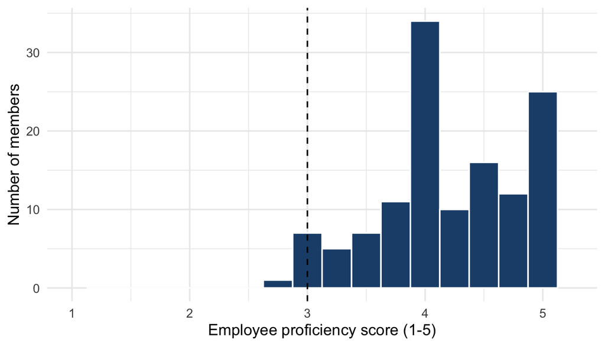

Figure 1: Distribution of the employee proficiency score (dashed line = midpoint of 3)

```r
ggplot(data_analysis, aes(x = att_employee)) +
  geom_histogram(binwidth = 0.25, fill = "#1f4e79", color = "white") +
  geom_vline(xintercept = 3, linetype = "dashed") +
  scale_x_continuous(limits = c(1, 5.25), breaks = 1:5) +
  labs(x = "Employee proficiency score (1-5)", y = "Number of members")
```

## 2.2 One-group t-test (test value = 3)

```r
r3_results <- one_sample_row("att_employee", "Employee proficiency score")

r3_results |>
  mutate(p_text = fmt_p(p)) |>
  select(description, n, mean, sd, t, df, p_text) |>
  gt() |>
  fmt_number(columns = c(mean, sd, t), decimals = 2) |>
  cols_label(description = "Score", p_text = "Significance")
```

Table 3: R3: One-sample t-test of the employee proficiency score against the midpoint of 3

| Score | n | mean | sd | t | df | Significance |
| --- | --- | --- | --- | --- | --- | --- |
| Employee proficiency score | 128 | 4.21 | 0.59 | 22.95 | 127 | p < .001 |

```r
r3_mean <- round(r3_results |> pull(mean), 2)
r3_t <- round(r3_results |> pull(t), 2)
r3_df <- r3_results |> pull(df)
r3_p_text <- fmt_p(r3_results |> pull(p))
r3_percent_4_plus <- round(r3_composite_summary |> pull(percent_4_or_higher), 1)

r3_lowest_statement <- r3_summary |> slice_min(percent_agree, n = 1, with_ties = FALSE) |> pull(statement)
r3_lowest_percent <- round(r3_summary |> slice_min(percent_agree, n = 1, with_ties = FALSE) |> pull(percent_agree), 1)
r3_highest_statement <- r3_summary |> slice_max(percent_agree, n = 1, with_ties = FALSE) |> pull(statement)
r3_highest_percent <- round(r3_summary |> slice_max(percent_agree, n = 1, with_ties = FALSE) |> pull(percent_agree), 1)
```

## 2.3 R3 Interpretation

Members hold clearly favorable attitudes toward EFCU employees. The average employee proficiency score is 4.21 on the five-point scale, well above the neutral midpoint of 3 (t(127) = 22.95, p < .001; Table 3), and 75.8% of members have a score of 4 or higher (Table 2, Figure 1).

At the item level, most members agree with every statement (Table 1). The strongest endorsement is for *Q3: Employees are courteous* (89.8% agree), and the weakest is for *Q6: Employees are always available* (78.9% agree), which still reflects a clear majority.

**Insight:** employees are a strength of the credit union. Members see them as courteous, helpful, professional, and available, so employee behavior is unlikely to be the reason members borrow elsewhere.

# 3 R4a: Residence and attitude toward employee proficiency

## 3.1 Descriptive statistics and independent-groups t-test

```r
r4a_results <- group_ttest_row("att_employee", "Employee proficiency score")

r4a_results |>
  mutate(p_text = fmt_p(p)) |>
  select(description, n_hq, mean_hq, sd_hq, n_else, mean_else, sd_else, difference, t, df, p_text, cohens_d) |>
  gt() |>
  fmt_number(columns = c(mean_hq, sd_hq, mean_else, sd_else, difference, t, df, cohens_d), decimals = 2) |>
  cols_label(
    description = "Score",
    n_hq = "n (HQ area)", mean_hq = "Mean (HQ area)", sd_hq = "SD (HQ area)",
    n_else = "n (elsewhere)", mean_else = "Mean (elsewhere)", sd_else = "SD (elsewhere)",
    difference = "Difference", p_text = "Significance", cohens_d = "Cohen's d"
  )
```

Table 4: R4a: Employee proficiency score by residence (Welch independent-groups t-test)

| Score | n (HQ area) | Mean (HQ area) | SD (HQ area) | n (elsewhere) | Mean (elsewhere) | SD (elsewhere) | Difference | t | df | Significance | Cohen's d |
| --- | --- | --- | --- | --- | --- | --- | --- | --- | --- | --- | --- |
| Employee proficiency score | 57 | 4.28 | 0.57 | 71 | 4.14 | 0.61 | 0.14 | 1.30 | 122.49 | p = .195 | 0.23 |

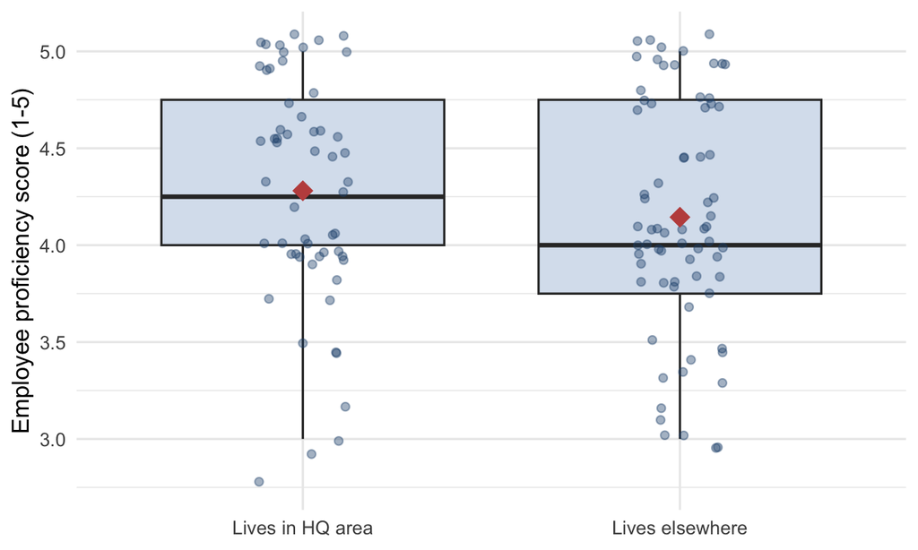

Figure 2: Employee proficiency score by residence (diamond = group mean)

```r
ggplot(data_analysis, aes(x = residence, y = att_employee)) +
  geom_boxplot(fill = "#d9e2ee", outlier.shape = NA) +
  geom_jitter(width = 0.12, alpha = 0.4, color = "#1f4e79") +
  stat_summary(fun = mean, geom = "point", shape = 18, size = 5, color = "#c0504d") +
  labs(x = NULL, y = "Employee proficiency score (1-5)")
```

```r
r4a_mean_hq <- round(r4a_results |> pull(mean_hq), 2)
r4a_mean_else <- round(r4a_results |> pull(mean_else), 2)
r4a_t <- round(r4a_results |> pull(t), 2)
r4a_df <- round(r4a_results |> pull(df), 1)
r4a_p <- r4a_results |> pull(p)
r4a_p_text <- fmt_p(r4a_p)
r4a_d <- round(r4a_results |> pull(cohens_d), 2)
r4a_sig_word <- if_else(r4a_p < .05, "a significant", "no significant")
```

## 3.2 R4a Interpretation

Members who live in the headquarters area rate employee proficiency at 4.28 on average, compared with 4.14 for members who live elsewhere (Table 4, Figure 2). There is no significant difference between the groups (t(122.5) = 1.3, p = .195; d = 0.23).

**Insight:** both groups are strongly positive about employees. Where a member lives does not change how they see employee proficiency, so employee service is consistently good for headquarters-area and out-of-area members alike.

# 4 R4b: Residence and awareness of services

## 4.1 Descriptive statistics

```r
service_labels <- var_label(select(data, q13:q26), unlist = TRUE)

service_names <- tibble(
  item = names(service_labels),
  service = str_to_sentence(unname(service_labels))
)

awareness_long <- data_analysis |>
  select(residence, q13:q26) |>
  pivot_longer(-residence, names_to = "item", values_to = "response")

awareness_counts <- awareness_long |>
  count(item, residence, response)

awareness_percent <- awareness_counts |>
  mutate(percent = n / sum(n) * 100, .by = c(item, residence))

awareness_percent <- awareness_percent |>
  left_join(service_names, by = "item")

# Percent unaware (code 3) and percent who have used the service (code 1) by group
unaware_by_group <- awareness_percent |>
  filter(response == 3) |>
  select(item, service, residence, percent_unaware = percent)

used_by_group <- awareness_percent |>
  filter(response == 1) |>
  select(item, residence, percent_used = percent)

awareness_by_group <- unaware_by_group |>
  left_join(used_by_group, by = c("item", "residence"))

awareness_wide <- awareness_by_group |>
  pivot_wider(
    names_from = residence,
    values_from = c(percent_unaware, percent_used),
    values_fill = 0
  )
```

```r
awareness_wide |>
  select(
    service,
    `percent_unaware_Lives in HQ area`, `percent_unaware_Lives elsewhere`,
    `percent_used_Lives in HQ area`, `percent_used_Lives elsewhere`
  ) |>
  gt() |>
  fmt_number(columns = -service, decimals = 1) |>
  cols_label(
    service = "Service",
    `percent_unaware_Lives in HQ area` = "Unaware: HQ area",
    `percent_unaware_Lives elsewhere` = "Unaware: elsewhere",
    `percent_used_Lives in HQ area` = "Used: HQ area",
    `percent_used_Lives elsewhere` = "Used: elsewhere"
  )
```

Table 5: R4b: Percent of members unaware of each service, and percent who have used it, by residence

| Service | Unaware: HQ area | Unaware: elsewhere | Used: HQ area | Used: elsewhere |
| --- | --- | --- | --- | --- |
| Regular share account | 59.6 | 69.0 | 12.3 | 8.5 |
| Special subaccounts | 38.6 | 33.8 | 7.0 | 11.3 |
| Christmas club account | 29.8 | 35.2 | 8.8 | 8.5 |
| Individual retirement accounts (ira) | 28.1 | 26.8 | 24.6 | 21.1 |
| Mastercard credit cards | 17.5 | 7.0 | 43.9 | 43.7 |
| Signature loans | 7.0 | 1.4 | 14.0 | 15.5 |
| New car loans | 3.5 | 4.2 | 17.5 | 19.7 |
| Late model car loans | 14.0 | 5.6 | 10.5 | 11.3 |
| Older model car loans | 26.3 | 25.4 | 7.0 | 11.3 |
| Household goods/appliance loans | 33.3 | 25.4 | 8.8 | 8.5 |
| Recreational loans | 38.6 | 46.5 | 8.8 | 11.3 |
| Share collateralized loan | 54.4 | 53.5 | 1.8 | 1.4 |
| Ira loans | 63.2 | 59.2 | NA | 5.6 |

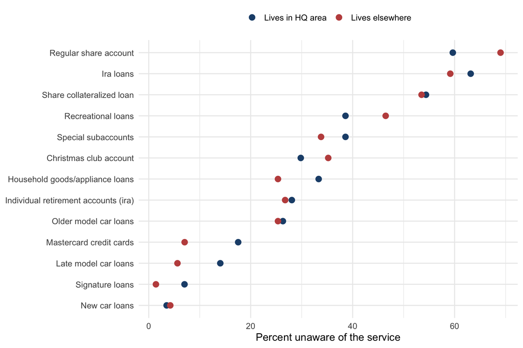

Figure 3: Percent of members unaware of each service, by residence

```r
service_order <- awareness_by_group |>
  summarise(avg_unaware = mean(percent_unaware), .by = service) |>
  arrange(avg_unaware) |>
  pull(service)

unaware_plot_data <- awareness_by_group |>
  mutate(service = factor(service, levels = service_order))

ggplot(unaware_plot_data, aes(x = percent_unaware, y = service, color = residence)) +
  geom_point(size = 3) +
  scale_color_manual(values = c("Lives in HQ area" = "#1f4e79", "Lives elsewhere" = "#c0504d")) +
  labs(x = "Percent unaware of the service", y = NULL, color = NULL) +
  theme(legend.position = "top")
```

## 4.2 Chi-square tests of independence

```r
r4b_results <- bind_rows(
  chisq_row("q13", "Regular share accounts"),
  chisq_row("q14", "Special subaccounts"),
  chisq_row("q15", "Christmas club accounts"),
  chisq_row("q16", "Individual retirement accounts"),
  chisq_row("q17", "MasterCard credit cards"),
  chisq_row("q18", "Signature loans"),
  chisq_row("q19", "New car loans"),
  chisq_row("q20", "Late model car loans"),
  chisq_row("q21", "Older model car loans"),
  chisq_row("q22", "Household goods/appliance loans"),
  chisq_row("q23", "Recreational loans"),
  chisq_row("q24", "Share collateralized loans"),
  chisq_row("q25", "IRA loans"),
  chisq_row("q26", "Line of credit loans")
)

# Adjust for running 14 tests (Holm method)
r4b_results <- r4b_results |>
  mutate(p_holm = p.adjust(p_reported, method = "holm"))

r4b_results |>
  mutate(
    p_text = fmt_p(p_reported),
    p_holm_text = fmt_p(p_holm),
    test_used = if_else(min_expected < 5, "Fisher exact", "Chi-square")
  ) |>
  select(description, n, chi_square, df, p_text, test_used, p_holm_text, cramers_v) |>
  gt() |>
  fmt_number(columns = c(chi_square, cramers_v), decimals = 2) |>
  cols_label(
    description = "Service", chi_square = "Chi-square", p_text = "p",
    test_used = "p based on", p_holm_text = "Holm-adjusted p", cramers_v = "Cramer's V"
  )
```

Table 6: R4b: Residence by awareness category (aware and used / aware, not used / unaware) for each service

| Service | n | Chi-square | df | p | p based on | Holm-adjusted p | Cramer's V |
| --- | --- | --- | --- | --- | --- | --- | --- |
| Regular share accounts | 128 | 1.27 | 2 | p = .529 | Chi-square | p = 1.000 | 0.10 |
| Special subaccounts | 128 | 0.81 | 2 | p = .666 | Chi-square | p = 1.000 | 0.08 |
| Christmas club accounts | 128 | 0.42 | 2 | p = .860 | Fisher exact | p = 1.000 | 0.06 |
| Individual retirement accounts | 128 | 0.33 | 2 | p = .849 | Chi-square | p = 1.000 | 0.05 |
| MasterCard credit cards | 128 | 3.79 | 2 | p = .150 | Chi-square | p = 1.000 | 0.17 |
| Signature loans | 128 | 2.66 | 2 | p = .319 | Fisher exact | p = 1.000 | 0.14 |
| New car loans | 128 | 0.16 | 2 | p = .938 | Fisher exact | p = 1.000 | 0.03 |
| Late model car loans | 128 | 2.63 | 2 | p = .269 | Chi-square | p = 1.000 | 0.14 |
| Older model car loans | 128 | 0.67 | 2 | p = .714 | Chi-square | p = 1.000 | 0.07 |
| Household goods/appliance loans | 128 | 1.05 | 2 | p = .622 | Fisher exact | p = 1.000 | 0.09 |
| Recreational loans | 128 | 1.38 | 2 | p = .502 | Chi-square | p = 1.000 | 0.10 |
| Share collateralized loans | 128 | 0.04 | 2 | p = 1.000 | Fisher exact | p = 1.000 | 0.02 |
| IRA loans | 128 | 3.32 | 2 | p = .242 | Fisher exact | p = 1.000 | 0.16 |
| Line of credit loans | 128 | 0.26 | 1 | p = .613 | Chi-square | p = 1.000 | 0.04 |

```r
r4b_n_tests <- nrow(r4b_results)
r4b_n_sig <- r4b_results |> filter(p_reported < .05) |> nrow()
r4b_n_sig_holm <- r4b_results |> filter(p_holm < .05) |> nrow()
r4b_max_v <- round(max(r4b_results |> pull(cramers_v)), 2)

r4b_largest_gap_row <- awareness_wide |>
  mutate(gap = abs(`percent_unaware_Lives in HQ area` - `percent_unaware_Lives elsewhere`)) |>
  slice_max(gap, n = 1, with_ties = FALSE)

r4b_largest_gap_service <- r4b_largest_gap_row |> pull(service)
r4b_largest_gap_points <- round(r4b_largest_gap_row |> pull(gap), 1)
```

## 4.3 R4b Interpretation

Awareness of EFCU services is very similar for members who live in the headquarters area and members who live elsewhere (Table 5, Figure 3). Of the 14 services tested, 0 show a statistically significant association with residence, and 0 remain significant after adjusting for the number of tests (Table 6). The associations that do appear are small (Cramer’s V is at most 0.17). The largest raw gap is for *Mastercard credit cards*, where the share unaware differs by about 10.5 percentage points between the groups.

# 5 R4c: Residence and operational effectiveness

## 5.1 Descriptive statistics and independent-groups t-tests (rating items)

```r
# Q10 and Q37 use the reversed versions (higher = better)
r4c_ttest_results <- bind_rows(
  group_ttest_row("q10r", "Q10: Accuracy of statements (1-4)"),
  group_ttest_row("q31", "Q31: Personnel keep information confidential"),
  group_ttest_row("q32", "Q32: Prompt in processing loan applications"),
  group_ttest_row("q33", "Q33: Services meet needs of members"),
  group_ttest_row("q34", "Q34: Loan applications simple and easy"),
  group_ttest_row("q37r", "Q37: Overall management and operation")
)

# Adjust for running 6 tests (Holm method)
r4c_ttest_results <- r4c_ttest_results |>
  mutate(p_holm = p.adjust(p, method = "holm"))

r4c_ttest_results |>
  mutate(p_text = fmt_p(p), p_holm_text = fmt_p(p_holm)) |>
  select(description, mean_hq, mean_else, difference, t, df, p_text, p_holm_text, cohens_d) |>
  gt() |>
  fmt_number(columns = c(mean_hq, mean_else, difference, t, df, cohens_d), decimals = 2) |>
  cols_label(
    description = "Item", mean_hq = "Mean (HQ area)", mean_else = "Mean (elsewhere)",
    difference = "Difference", p_text = "p", p_holm_text = "Holm-adjusted p", cohens_d = "Cohen's d"
  )
```

Table 7: R4c: Operational effectiveness ratings by residence (Welch independent-groups t-tests)

| Item | Mean (HQ area) | Mean (elsewhere) | Difference | t | df | p | Holm-adjusted p | Cohen's d |
| --- | --- | --- | --- | --- | --- | --- | --- | --- |
| Q10: Accuracy of statements (1-4) | 3.49 | 3.45 | 0.04 | 0.35 | 117.53 | p = .724 | p = 1.000 | 0.06 |
| Q31: Personnel keep information confidential | 4.05 | 3.86 | 0.19 | 1.62 | 121.26 | p = .109 | p = .544 | 0.29 |
| Q32: Prompt in processing loan applications | 3.68 | 3.75 | −0.06 | −0.44 | 118.94 | p = .661 | p = 1.000 | −0.08 |
| Q33: Services meet needs of members | 3.60 | 3.59 | 0.00 | 0.04 | 112.93 | p = .968 | p = 1.000 | 0.01 |
| Q34: Loan applications simple and easy | 3.28 | 3.61 | −0.32 | −2.28 | 94.24 | p = .025 | p = .149 | −0.42 |
| Q37: Overall management and operation | 4.02 | 4.10 | −0.09 | −0.66 | 118.74 | p = .513 | p = 1.000 | −0.12 |

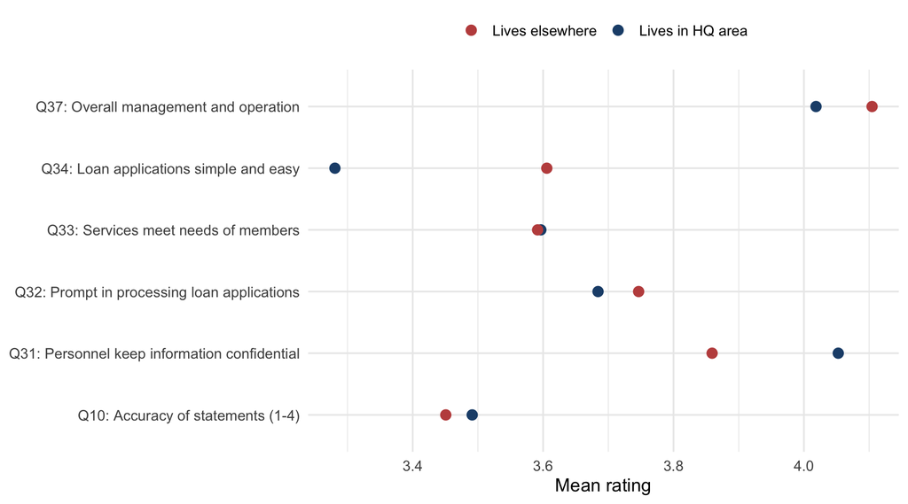

Figure 4: Mean ratings by residence for the operational effectiveness items

```r
r4c_plot_data <- r4c_ttest_results |>
  select(description, `Lives in HQ area` = mean_hq, `Lives elsewhere` = mean_else) |>
  pivot_longer(-description, names_to = "residence", values_to = "mean_rating")

ggplot(r4c_plot_data, aes(x = mean_rating, y = description, color = residence)) +
  geom_point(size = 3) +
  scale_color_manual(values = c("Lives in HQ area" = "#1f4e79", "Lives elsewhere" = "#c0504d")) +
  labs(x = "Mean rating", y = NULL, color = NULL) +
  theme(legend.position = "top")
```

## 5.2 Chi-square tests of independence (categorical items)

```r
r4c_cat_items <- data_analysis |>
  select(residence, q11, q12) |>
  mutate(q9_about_right = if_else(data_numeric |> pull(q9) == 3, 1, 0)) |>
  mutate(q11 = if_else(q11 == 1, 1, if_else(q11 == 2, 0, NA_real_)))

r4c_cat_items <- r4c_cat_items |>
  mutate(q12 = if_else(q12 == 1, 1, if_else(q12 == 2, 0, NA_real_)))

r4c_pct_table <- r4c_cat_items |>
  pivot_longer(-residence, names_to = "item", values_to = "value") |>
  summarise(percent_yes = mean(value, na.rm = TRUE) * 100, .by = c(item, residence)) |>
  pivot_wider(names_from = residence, values_from = percent_yes)

r4c_pct_table <- r4c_pct_table |>
  mutate(
    description = case_match(
      item,
      "q9_about_right" ~ "Q9: Statement frequency is about right",
      "q11" ~ "Q11: Statements easy to understand (yes)",
      "q12" ~ "Q12: Account information kept confidential (yes)"
    )
  ) |>
  select(description, `Lives in HQ area`, `Lives elsewhere`)

r4c_pct_table |>
  gt() |>
  fmt_number(columns = c(`Lives in HQ area`, `Lives elsewhere`), decimals = 1)
```

Table 8: R4c: Percent giving each response, by residence

| description | Lives in HQ area | Lives elsewhere |
| --- | --- | --- |
| Q11: Statements easy to understand (yes) | 96.5 | 98.6 |
| Q12: Account information kept confidential (yes) | 63.3 | 75.4 |
| Q9: Statement frequency is about right | 78.9 | 76.1 |

```r
# Q9 is recoded: 1 = about right, 0 = not about right
data_analysis <- data_analysis |>
  mutate(q9_about_right = if_else(q9 == 3, 1, 0))

r4c_chisq_results <- bind_rows(
  chisq_row("q9_about_right", "Q9: Statement frequency about right"),
  chisq_row("q11", "Q11: Statements easy to understand"),
  chisq_row("q12", "Q12: Account information confidential")
)

r4c_chisq_results <- r4c_chisq_results |>
  mutate(p_holm = p.adjust(p_reported, method = "holm"))

r4c_chisq_results |>
  mutate(
    p_text = fmt_p(p_reported),
    p_holm_text = fmt_p(p_holm),
    test_used = if_else(min_expected < 5, "Fisher exact", "Chi-square")
  ) |>
  select(description, n, chi_square, df, p_text, test_used, p_holm_text, cramers_v) |>
  gt() |>
  fmt_number(columns = c(chi_square, cramers_v), decimals = 2) |>
  cols_label(
    description = "Item", chi_square = "Chi-square", p_text = "p",
    test_used = "p based on", p_holm_text = "Holm-adjusted p", cramers_v = "Cramer's V"
  )
```

Table 9: R4c: Chi-square tests of independence (Fisher exact test where any expected count is below 5)

| Item | n | Chi-square | df | p | p based on | Holm-adjusted p | Cramer's V |
| --- | --- | --- | --- | --- | --- | --- | --- |
| Q9: Statement frequency about right | 128 | 0.15 | 1 | p = .698 | Chi-square | p = 1.000 | 0.03 |
| Q11: Statements easy to understand | 128 | 0.61 | 1 | p = .585 | Fisher exact | p = 1.000 | 0.07 |
| Q12: Account information confidential | 106 | 1.85 | 1 | p = .173 | Chi-square | p = .520 | 0.13 |

```r
r4c_sig_items <- r4c_ttest_results |> filter(p < .05)
r4c_n_sig_ttests <- nrow(r4c_sig_items)
r4c_n_sig_holm <- r4c_ttest_results |> filter(p_holm < .05) |> nrow()
r4c_n_sig_chisq <- r4c_chisq_results |> filter(p_reported < .05) |> nrow()

q34_row <- r4c_ttest_results |> filter(item == "q34")
q34_mean_hq <- round(q34_row |> pull(mean_hq), 2)
q34_mean_else <- round(q34_row |> pull(mean_else), 2)
q34_t <- round(q34_row |> pull(t), 2)
q34_df <- round(q34_row |> pull(df), 1)
q34_p_text <- fmt_p(q34_row |> pull(p))
q34_holm_text <- fmt_p(q34_row |> pull(p_holm))
```

## 5.3 R4c Interpretation

Members in the headquarters area and elsewhere judge how EFCU operates in much the same way. Of the six rating items, 1 differ significantly by residence, and 0 of the three yes/no items do (Table 7, Table 9, Figure 4). The one rating difference is **Q34, simplicity of loan applications**: members living outside the headquarters area give a higher rating (3.61) than members who live in the headquarters area (3.28) (t(94.2) = -2.28, p = .025). That result is not strong evidence on its own: it is one of six tests, and its Holm-adjusted p-value is p = .149, so it should be treated as a lead to explore and not a confirmed difference.

**Insight:** operations are judged similarly by both groups (statements, confidentiality, speed, meeting needs, and overall management). If any group needs attention, it is the headquarters-area members and the loan application process, where ratings are lowest in the data.

# 6 R6: Attitudes toward how effectively the credit union is operated

The earlier analysis showed that Q31 to Q34 do not form a reliable scale, so each is analyzed on its own.

## 6.1 Descriptive statistics: statements (Q9 to Q12)

```r
r6_q9 <- distribution_table("q9")
r6_q10 <- distribution_table("q10")
r6_q11 <- distribution_table("q11")
r6_q12 <- distribution_table("q12")

r6_frequencies <- bind_rows(r6_q9, r6_q10, r6_q11, r6_q12)

r6_variable_names <- c(
  q9 = "Q9: How often statements are received",
  q10 = "Q10: Accuracy of statements",
  q11 = "Q11: Statements easy to understand",
  q12 = "Q12: Account information kept confidential"
)

r6_frequencies |>
  filter(!is.na(code)) |>
  mutate(variable = r6_variable_names[variable]) |>
  select(variable, response, n, percent_of_valid) |>
  gt(groupname_col = "variable") |>
  cols_label(response = "Response", n = "n", percent_of_valid = "% of valid")
```

Table 10: R6: Account statements (percent of valid responses)

| Response | n | % of valid |
| --- | --- | --- |
| Q9: How often statements are received |  |  |
| About Right | 99 | 77.3 |
| Not Often Enough | 29 | 22.7 |
| Q10: Accuracy of statements |  |  |
| Excellent | 68 | 53.1 |
| Good | 54 | 42.2 |
| Fair | 4 | 3.1 |
| Poor | 2 | 1.6 |
| Q11: Statements easy to understand |  |  |
| Yes | 125 | 97.7 |
| No | 3 | 2.3 |
| Q12: Account information kept confidential |  |  |
| Yes | 74 | 69.8 |
| No | 32 | 30.2 |

## 6.2 One-group t-tests for the attitude items (test value = 3)

```r
r6_results <- bind_rows(
  one_sample_row("q31", "Q31: Personnel keep information confidential"),
  one_sample_row("q32", "Q32: Prompt in processing loan applications"),
  one_sample_row("q33", "Q33: Services meet needs of members"),
  one_sample_row("q34", "Q34: Loan applications simple and easy"),
  one_sample_row("q37r", "Q37: Overall management and operation")
)

r6_results |>
  mutate(p_text = fmt_p(p)) |>
  select(description, n, mean, sd, percent_4_or_5, t, df, p_text) |>
  gt() |>
  fmt_number(columns = c(mean, sd, percent_4_or_5, t), decimals = 2) |>
  cols_label(
    description = "Item", percent_4_or_5 = "% rating 4-5",
    p_text = "Significance"
  )
```

Table 11: R6: One-sample t-tests against the midpoint of 3 (1-5 scales, higher = more favorable)

| Item | n | mean | sd | % rating 4-5 | t | df | Significance |
| --- | --- | --- | --- | --- | --- | --- | --- |
| Q31: Personnel keep information confidential | 128 | 3.95 | 0.68 | 78.12 | 15.74 | 127 | p < .001 |
| Q32: Prompt in processing loan applications | 128 | 3.72 | 0.79 | 60.16 | 10.25 | 127 | p < .001 |
| Q33: Services meet needs of members | 128 | 3.59 | 0.68 | 59.38 | 9.87 | 127 | p < .001 |
| Q34: Loan applications simple and easy | 128 | 3.46 | 0.78 | 57.81 | 6.66 | 127 | p < .001 |
| Q37: Overall management and operation | 121 | 4.07 | 0.73 | 84.30 | 16.13 | 120 | p < .001 |

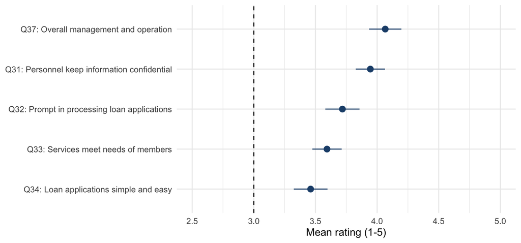

Figure 5: Mean rating with 95% confidence interval (dashed line = midpoint of 3)

```r
r6_plot_data <- r6_results |>
  mutate(description = fct_reorder(description, mean))

ggplot(r6_plot_data, aes(x = mean, y = description)) +
  geom_vline(xintercept = 3, linetype = "dashed") +
  geom_pointrange(aes(xmin = conf_low, xmax = conf_high), color = "#1f4e79") +
  scale_x_continuous(limits = c(2.5, 5)) +
  labs(x = "Mean rating (1-5)", y = NULL)
```

```r
r6_pct_about_right <- get_percent(r6_q9, 3)
r6_pct_accuracy_good <- get_percent(r6_q10, 1) + get_percent(r6_q10, 2)
r6_pct_understand_yes <- get_percent(r6_q11, 1)
r6_pct_confidential_yes <- get_percent(r6_q12, 1)

r6_n_sig_above <- r6_results |> filter(p < .05, mean > 3) |> nrow()
r6_highest_item <- r6_results |> slice_max(mean, n = 1, with_ties = FALSE) |> pull(description)
r6_lowest_item <- r6_results |> slice_min(mean, n = 1, with_ties = FALSE) |> pull(description)
r6_lowest_mean <- round(r6_results |> slice_min(mean, n = 1, with_ties = FALSE) |> pull(mean), 2)
r6_highest_mean <- round(r6_results |> slice_max(mean, n = 1, with_ties = FALSE) |> pull(mean), 2)
```

## 6.3 R6 Interpretation

Members view EFCU’s operations favorably. For statements, 77.3% say they arrive about as often as they should, 95.3% rate accuracy good or excellent, 97.7% find them easy to understand, and 69.8% say their account information is kept confidential (Table 10). On the agreement items, 5 of 5 have a mean significantly above the midpoint (Table 11, Figure 5). The highest-rated item is *Q37: Overall management and operation* (4.07), and the lowest is *Q34: Loan applications simple and easy* (3.46).

**Insight:** the basics (statements, confidentiality, overall management) are rated well. The weakest ratings are on loan-related items, which fits the board’s concern about members not borrowing from the credit union. Because Q31 to Q34 are not a single scale, these are reported as separate items and not as one “operational effectiveness” score.

# 7 Summary

| Question | Test | Result |
| --- | --- | --- |
| R3: Attitude toward employees | One-sample t-test of the Q3 to Q6 score vs. 3 | Strongly favorable (mean 4.21) |
| R4a: Residence and employee attitude | Independent-groups t-test | no significant difference (p = .195) |
| R4b: Residence and awareness | 14 chi-square / Fisher tests | 0 of 14 significant; 0 after adjustment |
| R4c: Residence and operations | t-tests (6 items) and chi-square / Fisher tests (3 items) | Only Q34 differs (not after adjustment) |
| R6: Operational effectiveness | Frequencies and one-sample t-tests, item by item | Favorable; loan-related items lowest |

## 7.1 Limitations

- The sample is small (n = 128), and the headquarters-area group has only 57 members, so group comparisons have limited power. Several awareness tables have cells with very few members.
- Rating items are ordinal; t-tests treat them as approximately interval.
- The reported p-values come from many tests; the Holm-adjusted p-values are shown to account for that.
- These are survey responses from members who returned the questionnaire, so non-response may affect how well they represent all members.

# 8 Appendix: Links